# Lecture 8 - Linear Regression and Multiple Regression

Matthew E. Aiello-Lammens

# Logistics

- Exam check-in
- Homework 4 will be posted by Tuesday evening
- Schedule individual meetings to discuss project

# Linear regression - review

**Written notes - page 1***

## Example of linear regression

Effects of starvation and humidity on water loss in the confused flour beetle. Here, looking at the relationship between humidity and weight loss

```r
flr_beetle <- read.csv(file = "https://mlammens.github.io/Biostats/data/Logan_Examples/Chapter8/Data/nelson.csv")
flr_beetle
```

```
##   HUMIDITY WEIGHTLOSS
## 1      0.0       8.98
## 2     12.0       8.14
## 3     29.5       6.67
## 4     43.0       6.08
## 5     53.0       5.90
## 6     62.5       5.83
## 7     75.5       4.68
## 8     85.0       4.20
## 9     93.0       3.72
```

Plot these data

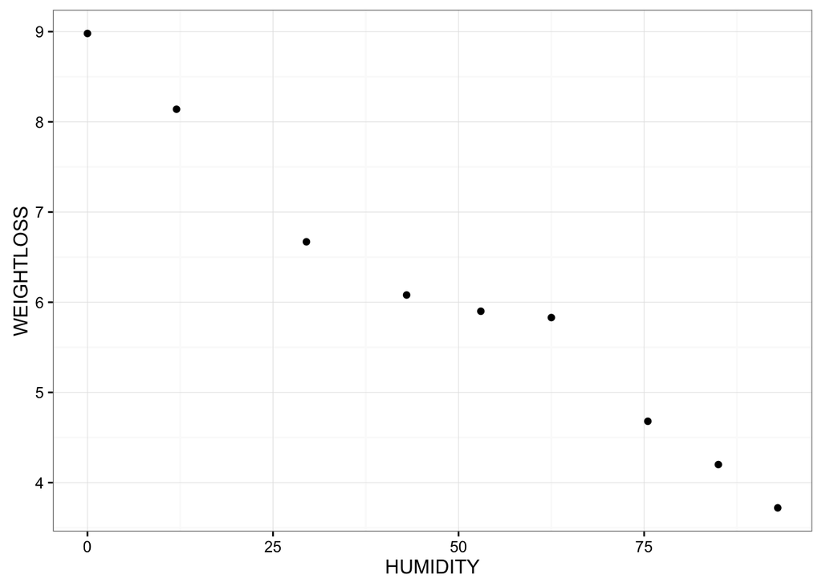

```r
library(ggplot2)

ggplot() +
  geom_point(data = flr_beetle, aes( x = HUMIDITY, y = WEIGHTLOSS)) +
  theme_bw()
```

Run a linear regression

```r
flr_beetle_lm <- lm(data = flr_beetle, WEIGHTLOSS ~ HUMIDITY)

summary(flr_beetle_lm)
```

```
##
## Call:
## lm(formula = WEIGHTLOSS ~ HUMIDITY, data = flr_beetle)
##
## Residuals:
##      Min       1Q   Median       3Q      Max
## -0.46397 -0.03437  0.01675  0.07464  0.45236
##
## Coefficients:
##              Estimate Std. Error t value Pr(>|t|)
## (Intercept)  8.704027   0.191565   45.44 6.54e-10 ***
## HUMIDITY    -0.053222   0.003256  -16.35 7.82e-07 ***
## ---
## Signif. codes:  0 '***' 0.001 '**' 0.01 '*' 0.05 '.' 0.1 ' ' 1
##
## Residual standard error: 0.2967 on 7 degrees of freedom
## Multiple R-squared:  0.9745, Adjusted R-squared:  0.9708
## F-statistic: 267.2 on 1 and 7 DF,  p-value: 7.816e-07
```

Plot these data, with `lm` fit

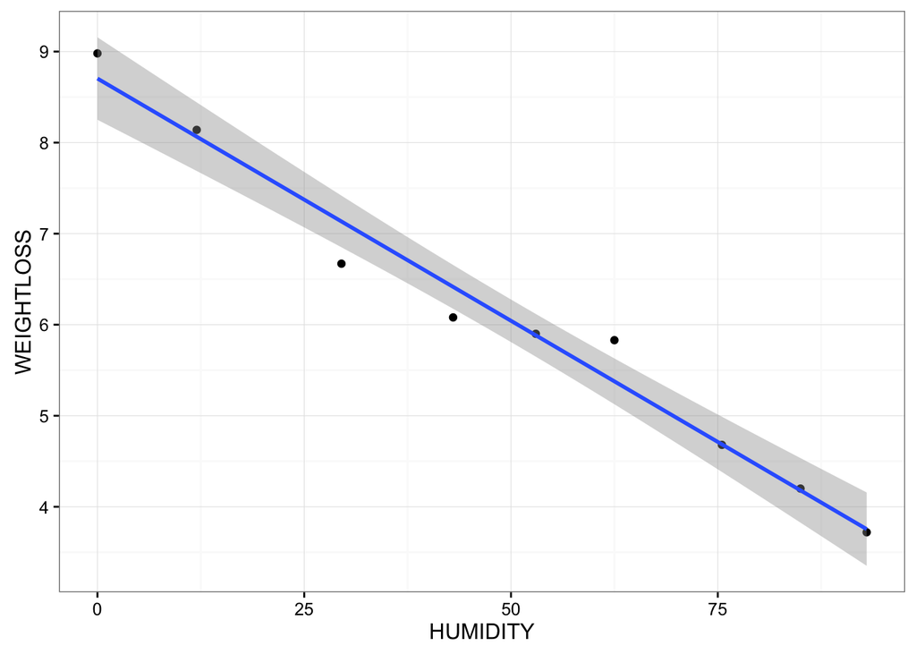

```r
ggplot(data = flr_beetle, aes( x = HUMIDITY, y = WEIGHTLOSS)) +
  geom_point() +
  stat_smooth(method = "lm") +
  theme_bw()
```

### Linear regression assumptions

#### The big three:

1. **Normality:** The $y_i$ **AND** error values ($\epsilon_i$) are normally distributed. If normality is violated, *p*-values and confidence intervals may be inaccurate and unreliable.
2. **Homogeneity of variance:** The $y_i$ **AND** error values ($\epsilon_i$) have the same variance for each $x_i$.
3. **Independence:** The $y_i$ **AND** error values are independent of *each other*.

#### Other assumptions:

- **Linearity:** The relationship between $x_i$ and $y_i$ is linear (only important when using simple linear regression).
- **Fixed X values:** The $x_i$ values are measured without error. In practice this means the error in the $x_i$ values is much smaller than that in the $y_i$ values.

### Linear regression diagnostics

- **Leverage:** a measure of how extreme a value in **x-space** is (i.e., along the x-axis) and how much of an influence each $x_i$ has on $\hat{y}_i$. High leverage values indicate that model is unduly influenced by an outlying value.
- **Residuals:** the differences between the observed $y_i$ values and the predicted $\hat{y}_i$ values. Looking at the pattern between residuals and $\hat{y}_i$ values can yield important information regarding violation of model assumptions (e.g., homogeneity of variance).
- **Cook’s D:** a statistics that offers a measure of the influence of each data point on the fitted model that incorporates both leverage and residuals. Values $\ge 1$ are considered “suspect”.

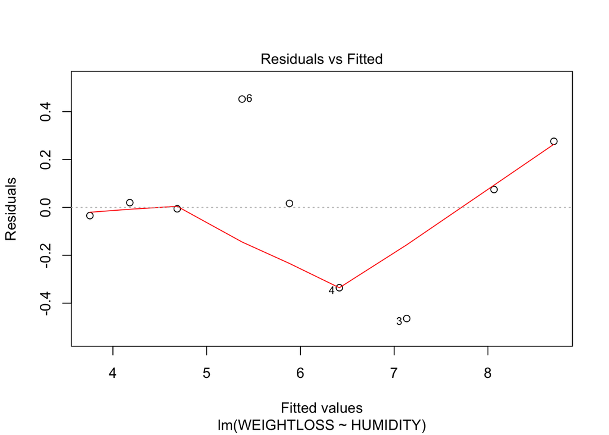

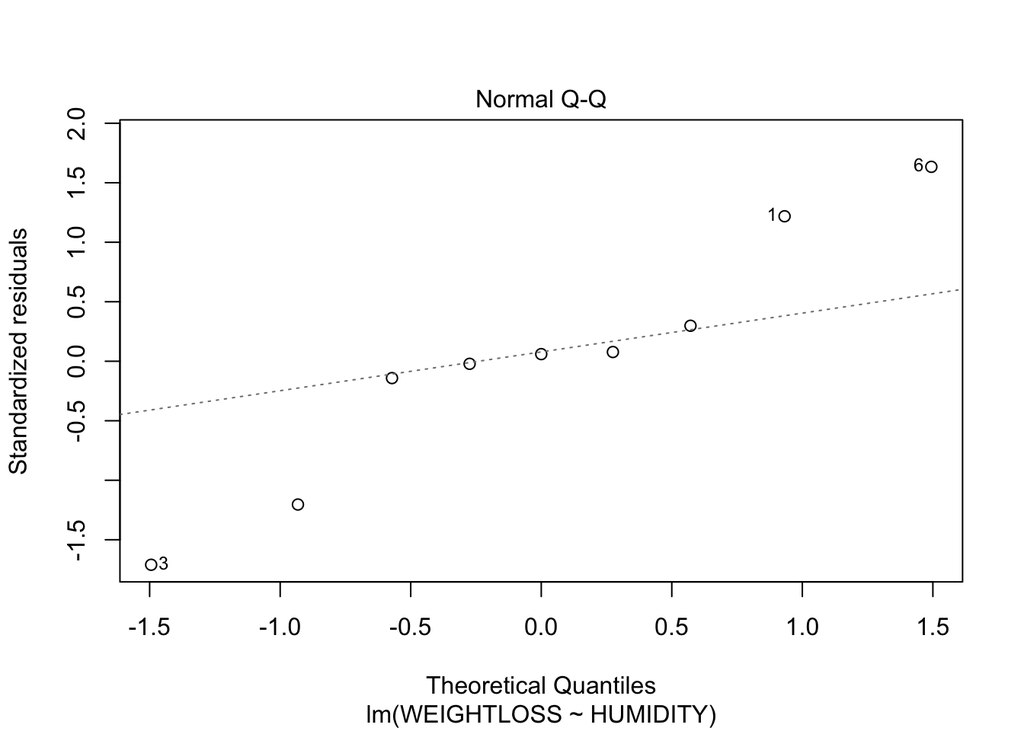

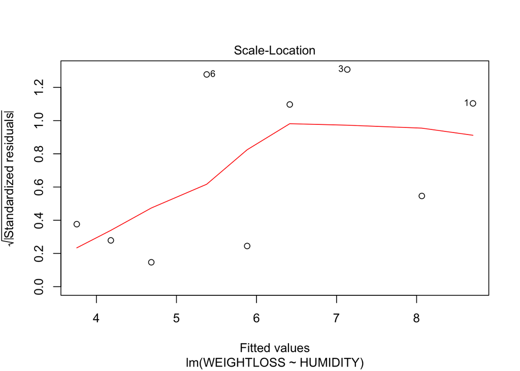

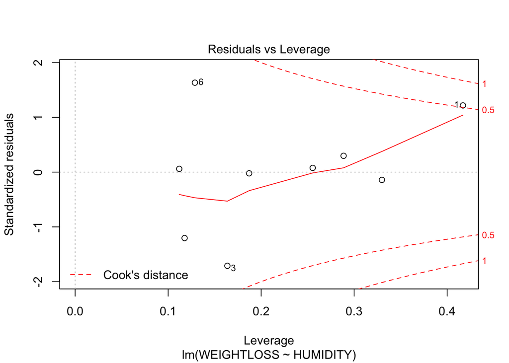

```r
plot(flr_beetle_lm)
```

## Standard error of regression coefficients, the regression line, and $\hat{y}_i$ predictions

Regression coefficients are statistics and thus we can determine the standard error of these statistics. From there, we can use these values and the *t*-distribution to determine confidence intervals. For example, the confidence interval for $b_1$ is:

$$b_1 \pm t_{0.05, n-2}s_{b_{1}}$$

### $\beta_1$ standard error

$$s_{b_{1}} = \sqrt{ \frac{MS_{Residual}}{\sum^n_{i=1}(x_i-\bar{x})^2} }$$

### $\beta_0$ standard error

$$s_{b_{0}} = \sqrt{ MS_{Residual} [\frac{1}{n} + \frac{\bar{x}^2}{\sum^n_{i=1}(x_i-\bar{x})^2}] }$$

### Confidence bands for regression line

From Quinn and Keough, p. 87:

> The 95% confidence band is a biconcave band that will contain the true population regression line 95% of the time.

### $\hat{y}_i$ standard error

$$s_{\hat{y}} = \sqrt{ MS_{Residual} [1 + \frac{1}{n} + \frac{x_p - \bar{x}^2}{\sum^n_{i=1}(x_i-\bar{x})^2}] }$$

where $x_p$ is the value from $x$ we are “predicting” a $y$ value for.

## My model looks good, but is it meaningful?

In order to determine if your linear regression model is meaningful (or *significant*) you must compare the **variance explained** by your model versus the **variance unexplained**.

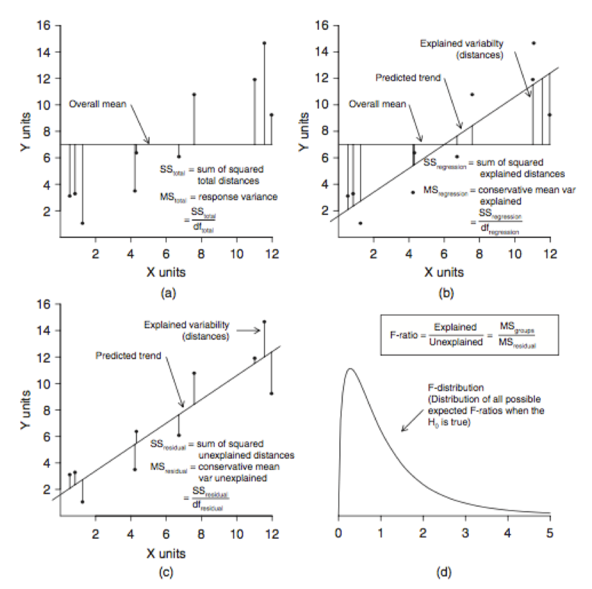

Note that there is a typo in this figure in panel (c). Instead of “Explained variability”, the arrow tag should be “Unexplained variability”.

# Regression and regression-like techniques we will not be covering in depth

Below is a list of techniques that are covered well in both of the class textbooks.

- Model II regression - e.g. Major axis regression. Used to deal with uncertain $x_i$ values
- Running medians - generation of predicted values ($\hat{y}_i$) that are *medians* of the responses in the bands surrounding each observation
- LOESS (or LOWESS) - local least-square regression fits, glued together
- kernel smoothers - weighted average values of $y_i$’s within a band of $x_i$ values
- splines - combined series of polynomial fits generated using windows of the data

# Multiple linear regression

What do we do when we have two or more predictors?

**See written notes – page 2**

Also, look at this totally awesome site! [Visualizing Relations in Multiple Regression](http://www.math.yorku.ca/SCS/spida/lm/visreg.html)

## Additive model

Only the predictors themselves are considered.

$$y_i = \beta_0 + \beta_1 x_{i1} + \beta_2 x_{i2} + ... + \beta_j x_{ij} + \epsilon_i$$

## Multiplicative model

The predictors **and the interactions** between predictors are considered.

$$y_i = \beta_0 + \beta_1 x_{i1} + \beta_2 x_{i2} + \beta_3 x_{i1} x_{i2} + ... + \beta_j x_{ij} + \epsilon_i$$

where $\beta_3 x_{i1} x_{i2}$ is the interactive effect of $X_1$ and $X_2$ on $Y$ and it examines the degree to which the effect of one of the predictor variables depends on the levels of the other (Logan p. 209).

**NOTE:** There are many more coefficients that need to be estimated in the multiplicative model!

## Additional assumption(s) to consider

- **(Multi)collinearity** - the predictor variables should not be highly correlated.

### Example of collinearity

Temperature in June and temperature in July

### Example of (potentially) meaningful interaction

Temperature in June and rainfall in June

### Assessing collinearity

- Look at pair-wise correlation values among all predictor variables
- calculate **tolerance**, or its inverse **Variance Inflation Factor**, for each predictor variable. For VIF, we should be cautios if values are greater than 5, and down right concerned if they are greater than 10.

## Example of addative multiple linear regression

Loyn (1987) investigated the effects of habitat fragmentation on abundance of forest birds. He considered multiple predictor variables associated with fragmentation or other important environmental conditions.

Get data and examine.

```r
bird_frag <- read.csv(file = "https://mlammens.github.io/Biostats/data/Logan_Examples/Chapter9/Data/loyn.csv")
summary(bird_frag)
```

```
##      ABUND            AREA            YR.ISOL          DIST
##  Min.   : 1.50   Min.   :   0.10   Min.   :1890   Min.   :  26.0
##  1st Qu.:12.40   1st Qu.:   2.00   1st Qu.:1928   1st Qu.:  93.0
##  Median :21.05   Median :   7.50   Median :1962   Median : 234.0
##  Mean   :19.51   Mean   :  69.27   Mean   :1950   Mean   : 240.4
##  3rd Qu.:28.30   3rd Qu.:  29.75   3rd Qu.:1966   3rd Qu.: 333.2
##  Max.   :39.60   Max.   :1771.00   Max.   :1976   Max.   :1427.0
##      LDIST            GRAZE            ALT
##  Min.   :  26.0   Min.   :1.000   Min.   : 60.0
##  1st Qu.: 158.2   1st Qu.:2.000   1st Qu.:120.0
##  Median : 338.5   Median :3.000   Median :140.0
##  Mean   : 733.3   Mean   :2.982   Mean   :146.2
##  3rd Qu.: 913.8   3rd Qu.:4.000   3rd Qu.:182.5
##  Max.   :4426.0   Max.   :5.000   Max.   :260.0
```

Plot these data.

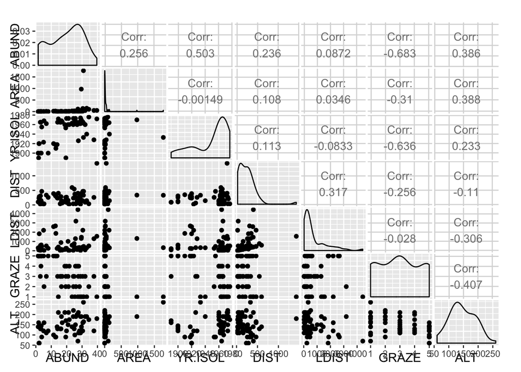

```r
library(GGally)
ggpairs(bird_frag)
```

We can clearly see here that some of our predictor variables are **not normally distributed**, particularly AREA, and to a lesser extent DIST and LDIST. We will try to transform these data, to see if we can get them to look a bit more normal.

```r
bird_frag_transform <- bird_frag

bird_frag_transform$AREA <- log10(bird_frag$AREA)
bird_frag_transform$DIST <- log10(bird_frag$DIST)
bird_frag_transform$LDIST <- log10(bird_frag$LDIST)
```

Replot.

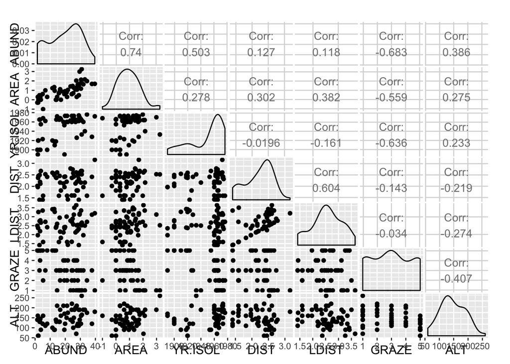

```r
ggpairs(bird_frag_transform)
```

We also see here that there are no extremely high correlations among the predictor variables. How we define “extremely high” is relatively arbitrary, but generally anything greater than 0.8.

To be safe, we’ll examine the VIFs.

```r
library(car)

vif(lm(data = bird_frag, ABUND ~ log10(AREA) + YR.ISOL + log10(DIST) + log10(LDIST) + GRAZE + ALT))
```

```
##  log10(AREA)      YR.ISOL  log10(DIST) log10(LDIST)        GRAZE
##     1.911514     1.804769     1.654553     2.009749     2.524814
##          ALT
##     1.467937
```

And, we’re good.

Now run the multiple linear regression model.

```r
bird_frag_lm <- lm(data = bird_frag, ABUND ~ log10(AREA) + YR.ISOL + log10(DIST) + log10(LDIST) + GRAZE + ALT)
```

Diagnostic plots.

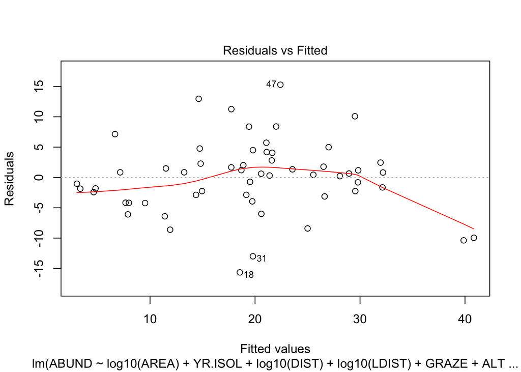

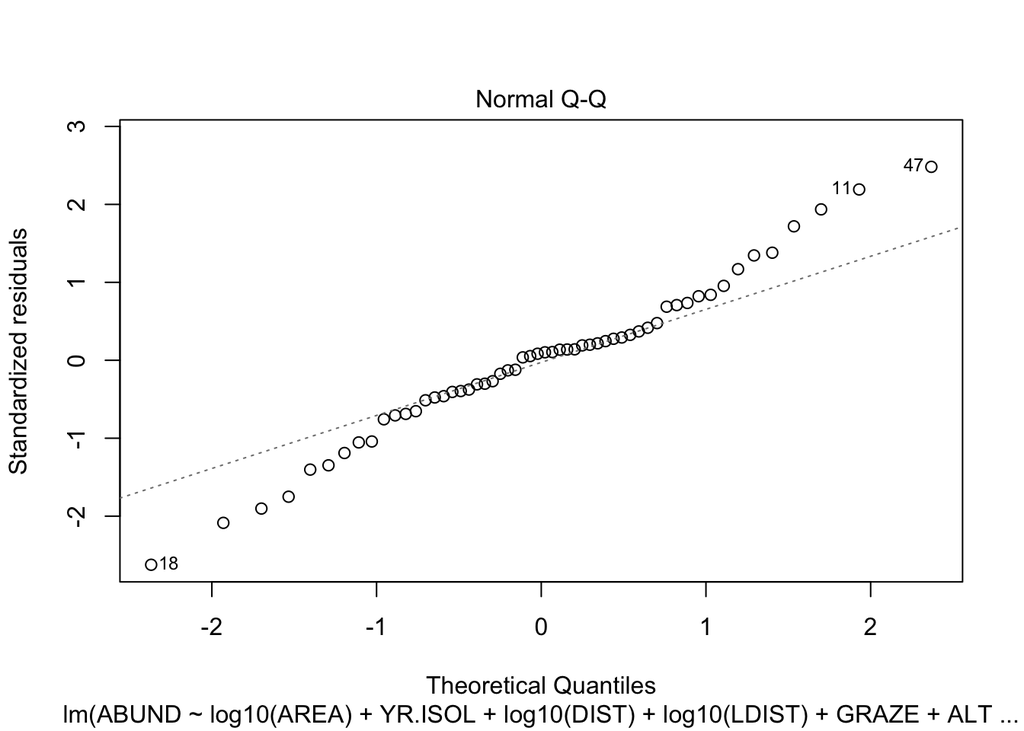

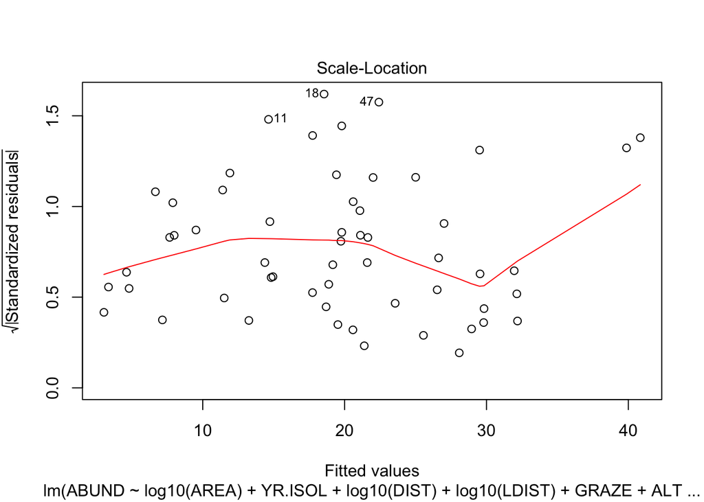

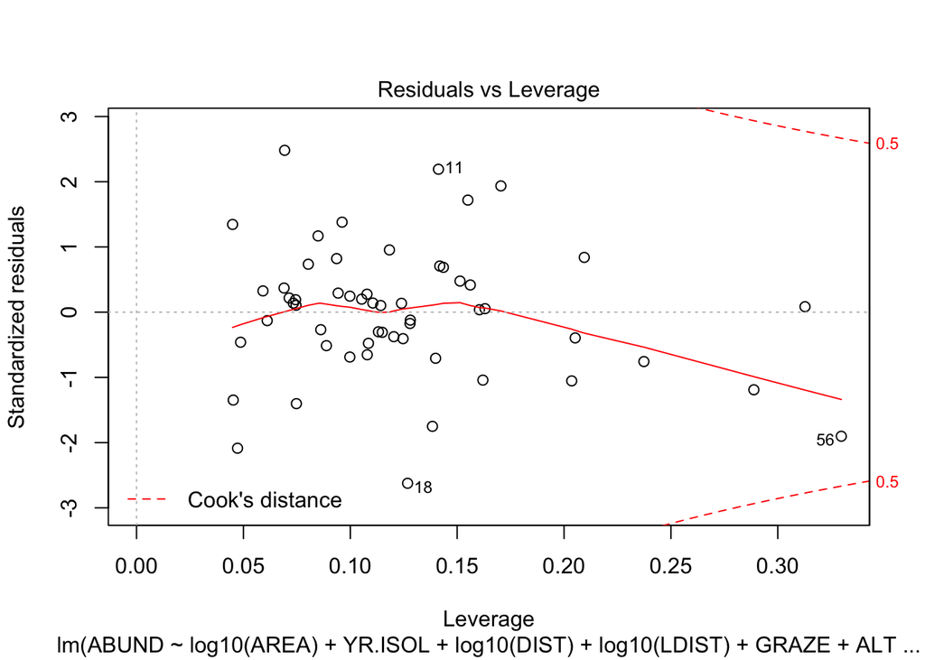

```r
plot(bird_frag_lm)
```

Looks good!

Now look at the model summary.

```r
summary(bird_frag_lm)
```

```
##
## Call:
## lm(formula = ABUND ~ log10(AREA) + YR.ISOL + log10(DIST) + log10(LDIST) +
##     GRAZE + ALT, data = bird_frag)
##
## Residuals:
##      Min       1Q   Median       3Q      Max
## -15.6506  -2.9390   0.5289   2.5353  15.2842
##
## Coefficients:
##                Estimate Std. Error t value Pr(>|t|)
## (Intercept)  -125.69725   91.69228  -1.371   0.1767
## log10(AREA)     7.47023    1.46489   5.099 5.49e-06 ***
## YR.ISOL         0.07387    0.04520   1.634   0.1086
## log10(DIST)    -0.90696    2.67572  -0.339   0.7361
## log10(LDIST)   -0.64842    2.12270  -0.305   0.7613
## GRAZE          -1.66774    0.92993  -1.793   0.0791 .
## ALT             0.01951    0.02396   0.814   0.4195
## ---
## Signif. codes:  0 '***' 0.001 '**' 0.01 '*' 0.05 '.' 0.1 ' ' 1
##
## Residual standard error: 6.384 on 49 degrees of freedom
## Multiple R-squared:  0.6849, Adjusted R-squared:  0.6464
## F-statistic: 17.75 on 6 and 49 DF,  p-value: 8.443e-11
```

What if we wanted to look at each partial regression plot? Use `av.plots` from the `car` package.

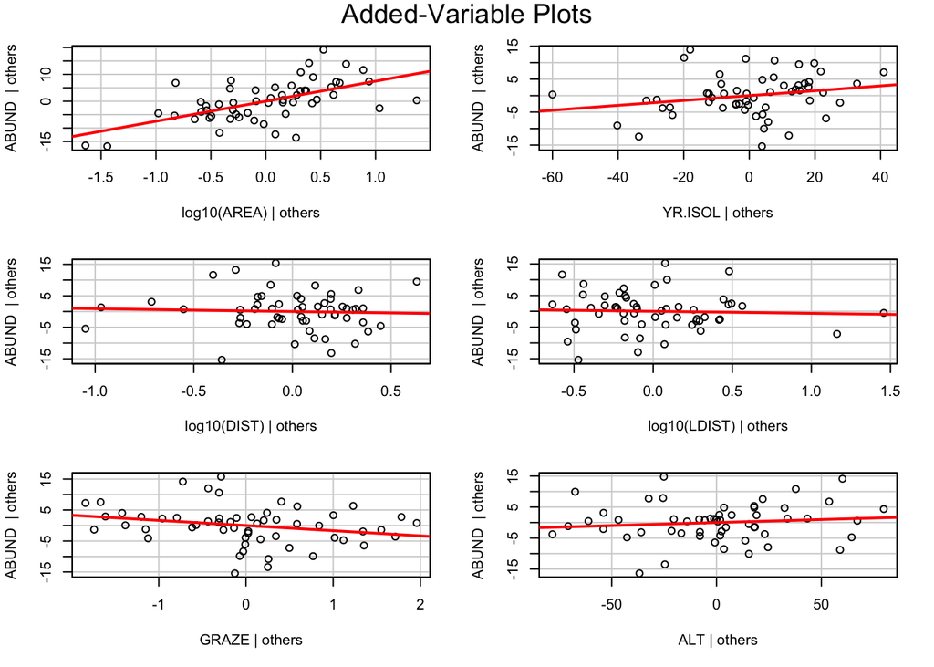

```r
avPlots(bird_frag_lm, ask = F)
```

Another way to **approximately visualize** these relationships.

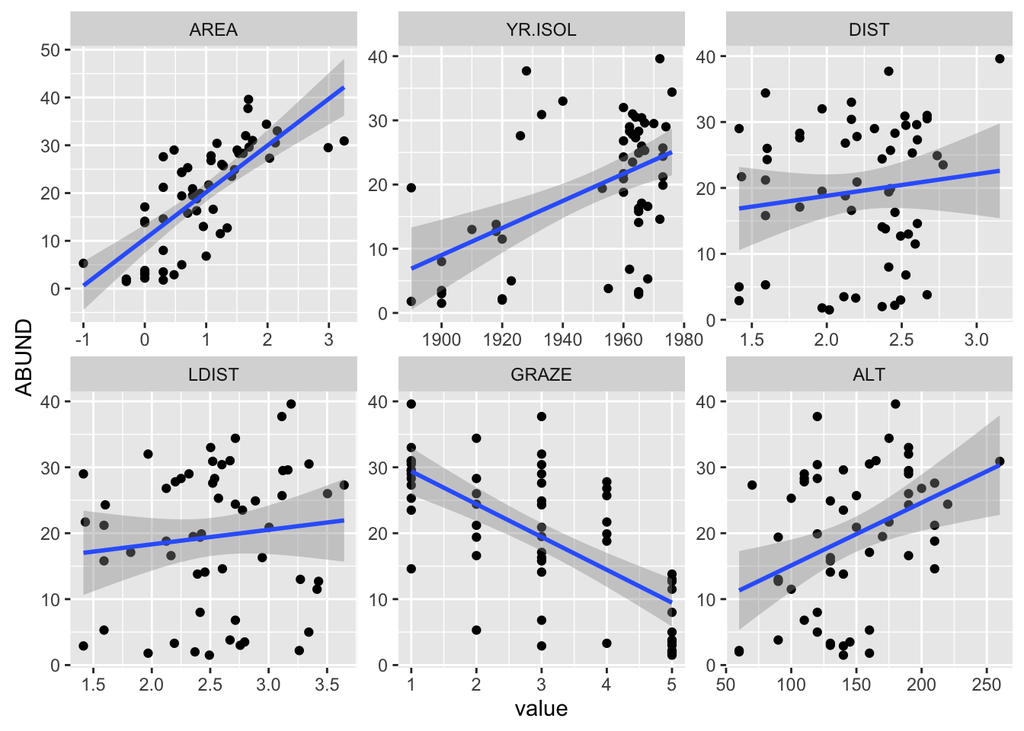

```r
library(reshape)

bird_frag_transform_melt <- melt(bird_frag_transform, id.vars = c("ABUND"))

ggplot(data = bird_frag_transform_melt, aes(x = value, y = ABUND)) +
  geom_point() +
  stat_smooth(method = "lm") +
  facet_wrap( ~variable, scales = "free" )
```